# ajy28_S&DS5300_Final_Project

## Introduction

In this project, I will be analyzing the Food dataset provided by the course. The main objective of this analysis is to identify variable relationships with the weight. Specifically, I would like to look at variables relating to lifestyle, demographics, and calorie perception. Lifestyle and demographic variables are included because they are known to have significant impact on weight. Meanwhile, calorie/nutrient perception is an interesting category to look at, because the existence of a relationship between calorie/nutrient knowledge and weight may place further emphasis on food education.

## Data

The following are the variables I ended up using, detailing both the prompt and response options when appropriate.

- “weight”: weight in lbs
- “Gender”: 1 = Female, 2 = Male
- “GPA”: Numerical, actual GPA
- “grade_level”:
  - 1 = freshman,
  - 2 = sophomore,
  - 3 = junior,
  - 4 = senior
- “healthy_feeling”: How likely to agree with “I feel very healthy!”?
  - Scale of 1-10 where 1 is strongly agree and 10 is strongly disagree.
- “self_perception_weight”: Self perception of weight
  - 1 = slim,
  - 2 = very fit,
  - 3 = just right,
  - 4 = slightly overweight,
  - 5 = overweight,
  - 6 = i dont think myself in these terms
- “exercise”: How often do you exercise in a regular week?
  - 1 = Everyday
  - 2 = Twice or three times per week
  - 3 = Once a week
  - 4 = Sometimes
  - 5 = Never
- “calories_day”: Importance of consuming calories per day
  - 1 = i dont know how many calories i should consume
  - 2 = it is not at all important
  - 3 = it is moderately important
  - 4 = it is very important
- “nutritional_check”: Checking nutritional values frequency
  - 1 = never
  - 2 = on certain products only
  - 3 = very rarely
  - 4 = on most products
  - 5 = on everything
- “calories_chicken”: Guessing calories in chicken piadina
  - 265
  - 430
  - 610
  - 720
- “waffle_calories”: Guessing calories in waffle potato sandwich
  - 575
  - 760
  - 900
  - 1315

## Data Cleaning Process

Because we know what variables we are keeping, we first read in the csv and subset to only include the relevant columns. Dimensions and column names are checked to see how much data is retained and to ensure variables are kept.

```
## [1] 125  11
```

```
##  [1] "weight"                 "Gender"                 "GPA"
##  [4] "grade_level"            "healthy_feeling"        "self_perception_weight"
##  [7] "exercise"               "calories_day"           "nutritional_check"
## [10] "calories_chicken"       "waffle_calories"
```

Afterwards, we check to see if there are any variables that have missing values, which, based on the output below, there seem to be a few in self_perception_weight, exercise, and calories_day.

```
##                 weight                 Gender                    GPA
##                      0                      0                      0
##            grade_level        healthy_feeling self_perception_weight
##                      0                      0                      1
##               exercise           calories_day      nutritional_check
##                     13                     19                      0
##       calories_chicken        waffle_calories
##                      0                      0
```

Because of these missing values, I went ahead and omitted any rows that had any missing values to ensure that we were working with full responses. The dimensions of the dataset were then checked and the output shown below.

```
## [1] 97 11
```

For additional quality control, I had checked GPA since that question seemed to be free response. I was looking for numerical values, and most of them were, but a couple had character text in them. To address this, I removed any non-numeric character, trimmed the whitespace, and converted the value to numeric. Additionally, any values at this point that did not have a number or were below 0 / above 4 were removed. The responses for GPA before and after cleaning are listed in the output below.

```
##  [1] "3.654"      "3.3"        "3.2"        "3.5"        "2.25"
##  [6] "3.8"        "3.3"        "3.3"        "3.5"        "3.904"
## [11] "3.4"        "3.6"        "3.1"        "4"          "3.6"
## [16] "3.4"        "2.2"        "3.3"        "3.87"       "3.7"
## [21] "3.7"        "2.8"        "3.7"        "3"          "3.2"
## [26] "3.5"        "4"          "4"          "2.8"        "3.65"
## [31] "3"          "3.7"        "3.4"        "3.89"       "3.4"
## [36] "2.9"        "3.2"        "3.8"        "3.83"       "3.6"
## [41] "3.3"        "3.3"        "3.5"        "3.35"       "3.8"
## [46] "2.8"        "3.5"        "3.6"        "Personal "  "3.9"
## [51] "2.6"        "3.5"        "3.6"        "3.2"        "3.67"
## [56] "3.73"       "3.1"        "3.79 bitch" "2.71"       "3"
## [61] "3.7"        "3.1"        "3"          "3.9"        "3.4"
## [66] "3.5"        "3.83"       "2.6"        "3"          "3.2"
## [71] "3.5"        "3.2"        "3.68"       "3.8"        "3.75"
## [76] "3.92"       "3.9"        "3.9"        "3.5"        "nan"
## [81] "3.7"        "3"          "3"          "3.8"        "3.8"
## [86] "3.4"        "3.7"        "2.9"        "3.9"        "3.6"
## [91] "2.8"        "3.3"        "3.63"       "3.2"        "3.5"
## [96] "3"          "3"
```

```
##  [1] 3.654 3.300 3.200 3.500 2.250 3.800 3.300 3.300 3.500 3.904 3.400 3.600
## [13] 3.100 4.000 3.600 3.400 2.200 3.300 3.870 3.700 3.700 2.800 3.700 3.000
## [25] 3.200 3.500 4.000 4.000 2.800 3.650 3.000 3.700 3.400 3.890 3.400 2.900
## [37] 3.200 3.800 3.830 3.600 3.300 3.300 3.500 3.350 3.800 2.800 3.500 3.600
## [49] 3.900 2.600 3.500 3.600 3.200 3.670 3.730 3.100 3.790 2.710 3.000 3.700
## [61] 3.100 3.000 3.900 3.400 3.500 3.830 2.600 3.000 3.200 3.500 3.200 3.680
## [73] 3.800 3.750 3.920 3.900 3.900 3.500 3.700 3.000 3.000 3.800 3.800 3.400
## [85] 3.700 2.900 3.900 3.600 2.800 3.300 3.630 3.200 3.500 3.000 3.000
```

Seeing as weight was also a free response question, the same QC process as GPA was applied. The responses for weight before and after cleaning are listed in the output below.

```
##  [1] "155"                      "I'm not answering this. "
##  [3] "Not sure, 240"            "190"
##  [5] "190"                      "180"
##  [7] "137"                      "125"
##  [9] "116"                      "110"
## [11] "264"                      "123"
## [13] "185"                      "145"
## [15] "170"                      "135"
## [17] "165"                      "175"
## [19] "195"                      "185"
## [21] "185"                      "125"
## [23] "160"                      "175"
## [25] "180"                      "167"
## [27] "115"                      "205"
## [29] "128"                      "150"
```

[output cut: 33 more lines]

```
##  [1] 155 240 190 190 180 137 125 116 110 264 123 185 145 170 135 165 175 195 185
## [20] 185 125 160 175 180 167 115 205 128 150 150 150 170 150 140 120 170 168 150
## [39] 169 185 200 165 192 175 140 155 135 210 180 140 144 145 130 140 140 200 120
## [58] 150 200 135 145 130 190 167 140 190 155 175 129 260 135 175 210 155 185 125
## [77] 130 125 130 165 128 200 160 170 129 170 138 150 140 185 156 180 135
```

All other variables in our subsetted dataset were multiple choice questions. Because we had already accounted for NA values earlier, no additional QC was needed.

## Descriptive Plots, Summary Information

To visualize the continuous variables, boxplots were made for GPA and weight.

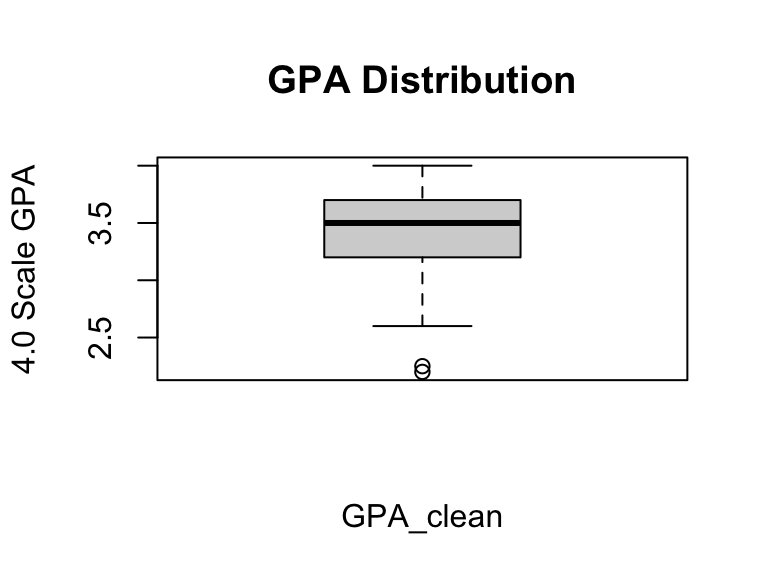

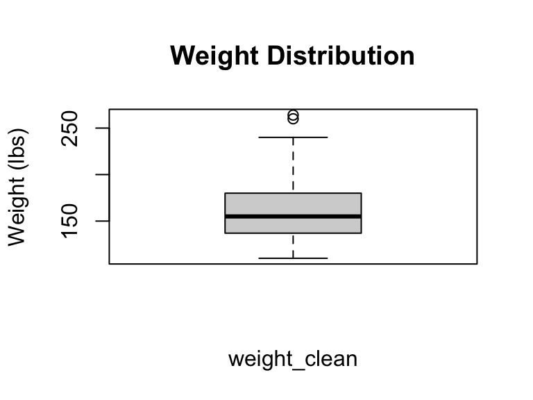

To visualize categorical variables, barplots were made that shows the response value on the x-axis, response count on the y-axis, as well as respective response count above each bar.

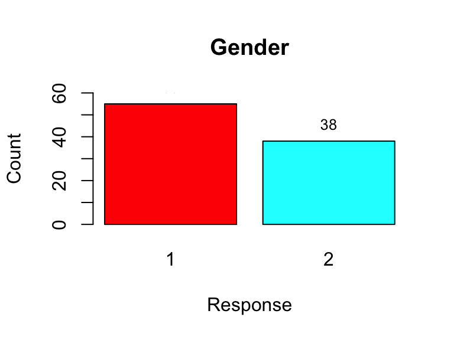

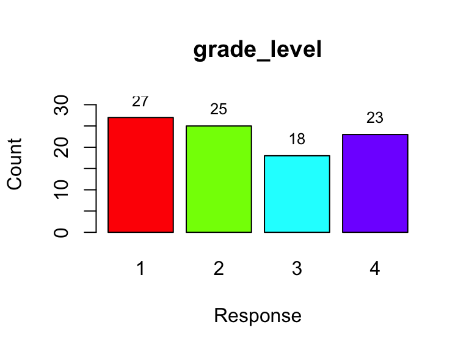

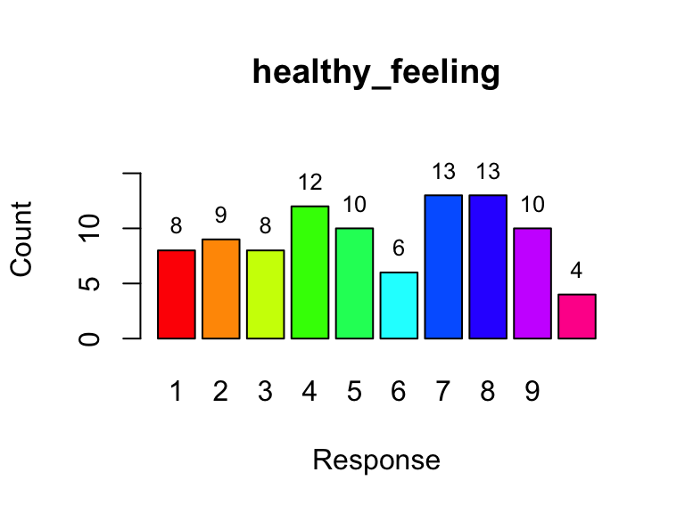

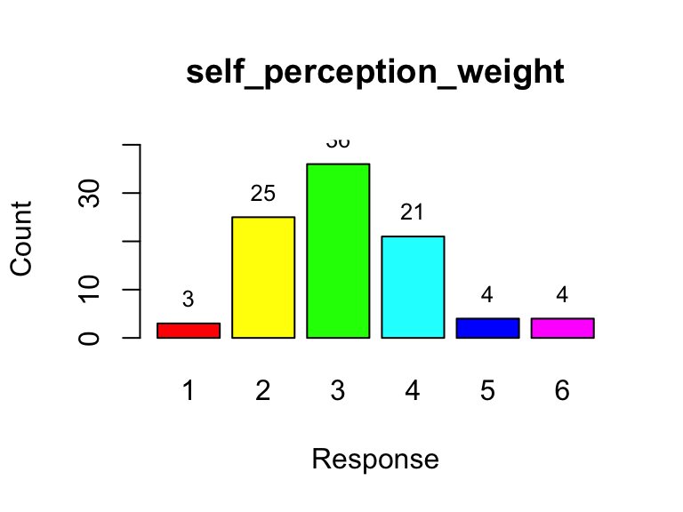

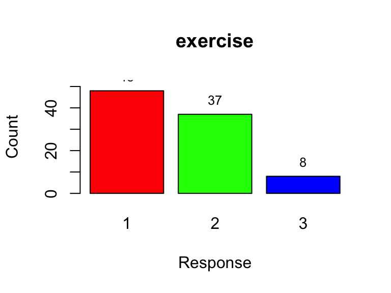

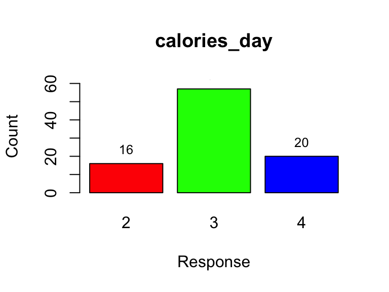

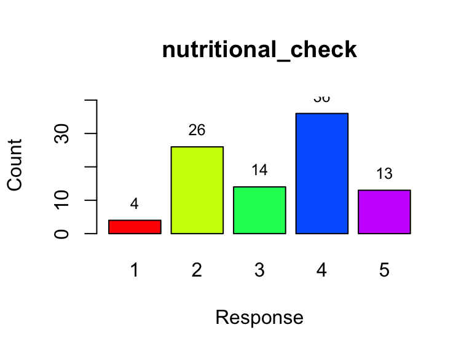

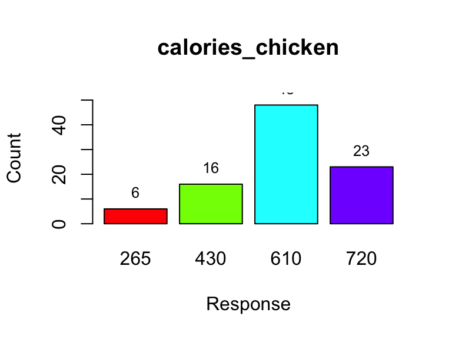

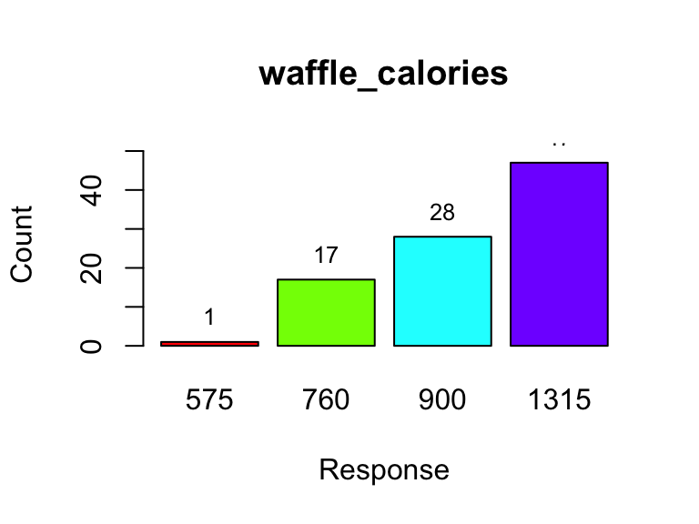

## Analysis

### Basic tests

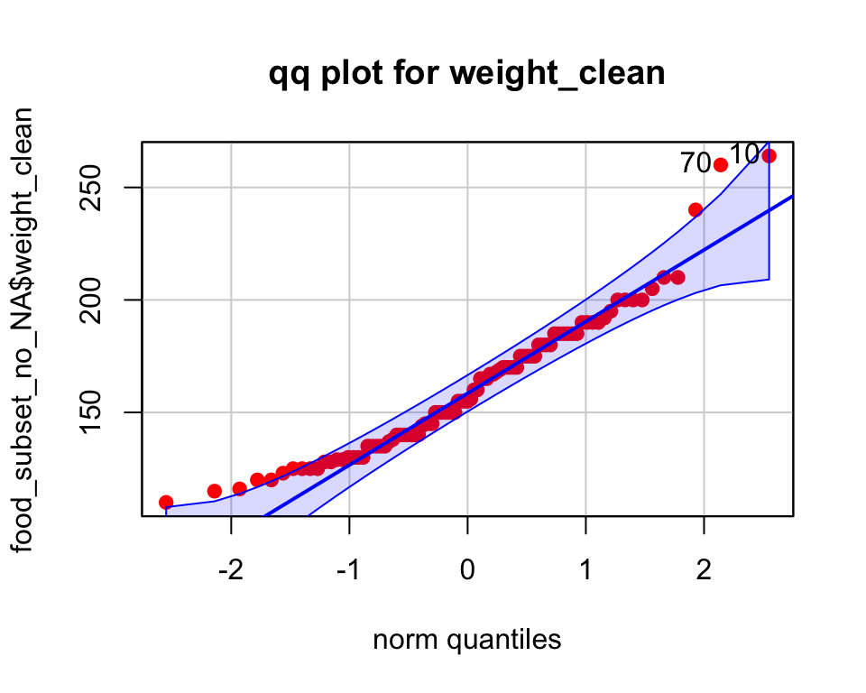

```
## [1] 10 70
```

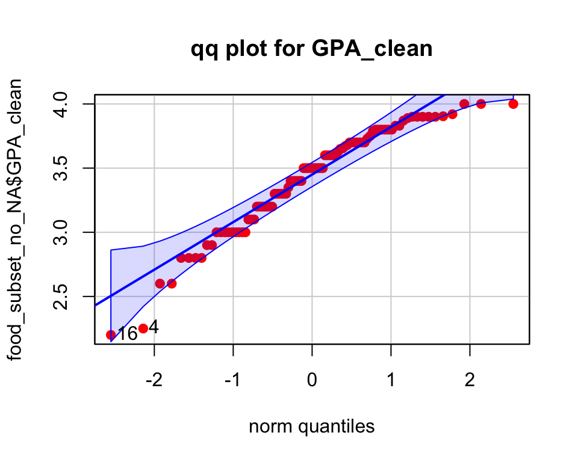

```
## [1] 16  4
```

```
##
##  Welch Two Sample t-test
##
## data:  weight_clean by Gender
## t = -5.1433, df = 75.241, p-value = 2.077e-06
## alternative hypothesis: true difference in means between group 1 and group 2 is not equal to 0
## 95 percent confidence interval:
##  -41.19941 -18.19580
## sample estimates:
## mean in group 1 mean in group 2
##        148.6182        178.3158
```

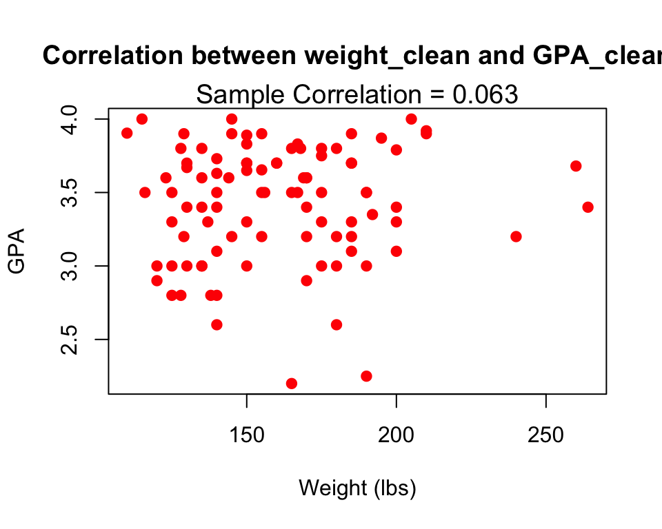

```
##   2.5%  97.5%
## -41.06 -18.54
```

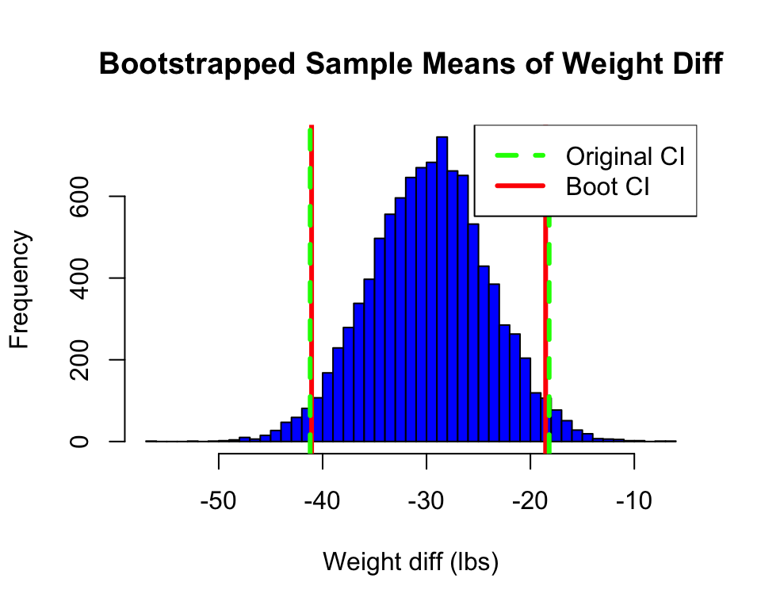

### Permutation Test

Here, a permutation test was performed between weight and gender to see if there is significant difference in weight between gender groups. Using a set seed and n = 10000, permutation was performed and the histogram output is shown below. In the histogram, we can see that our actual difference in means is above all permuted sample means difference in weight, with a p-value of 0 for our given n. This permutation test provides further support for significant difference in weight by gender.

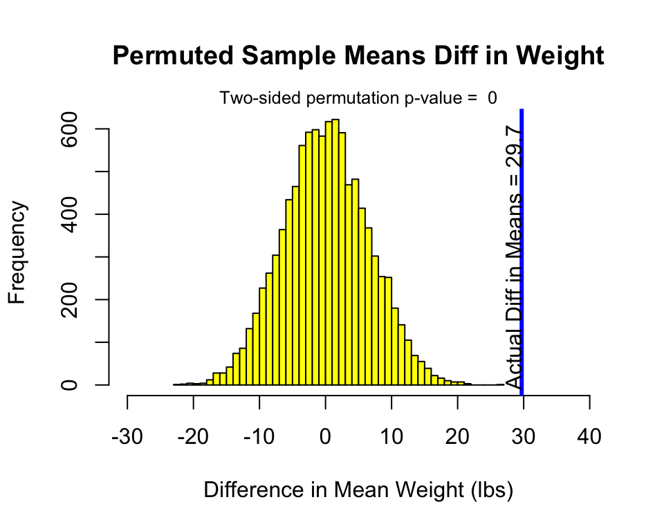

### Multiple Regression (Best Subset Regression)

Here, we run multiple best subsets regression (rsq, adjr2, bic) using all of the variables listed in the Data section to find the best model. The final model I chose to use is adjr2 because it seemed to avoid overfitting (rsq) and had a higher multiple R-squared than bic.

```
## [1] "rsq model"
```

```
##  [1] "Gender"                 "GPA_clean"              "grade_level"
##  [4] "healthy_feeling"        "self_perception_weight" "exercise"
##  [7] "calories_day"           "nutritional_check"      "calories_chicken"
## [10] "waffle_calories"
```

```
##
## Call:
## lm(formula = weight_clean ~ ., data = food_temp)
##
## Residuals:
##     Min      1Q  Median      3Q     Max
## -51.190 -14.076  -3.242  13.046  75.661
##
## Coefficients:
##                         Estimate Std. Error t value Pr(>|t|)
## (Intercept)            69.456633  34.018410   2.042 0.044393 *
## Gender                 34.356077   5.660875   6.069 3.81e-08 ***
## GPA_clean               1.773825   7.045523   0.252 0.801852
## grade_level             4.165377   2.453365   1.698 0.093334 .
## healthy_feeling        -0.128367   1.028281  -0.125 0.900958
## self_perception_weight  9.840548   2.590224   3.799 0.000278 ***
## exercise                2.249112   4.678100   0.481 0.631957
## calories_day            5.358769   5.113842   1.048 0.297766
## nutritional_check      -0.692066   2.613812  -0.265 0.791849
## calories_chicken       -0.024497   0.025714  -0.953 0.343557
## waffle_calories        -0.005816   0.012574  -0.463 0.644906
## ---
## Signif. codes:  0 '***' 0.001 '**' 0.01 '*' 0.05 '.' 0.1 ' ' 1
##
## Residual standard error: 24.96 on 82 degrees of freedom
## Multiple R-squared:  0.4054, Adjusted R-squared:  0.3329
## F-statistic: 5.591 on 10 and 82 DF,  p-value: 2.573e-06
```

```
## [1] "adjr2 model"
```

```
## [1] "Gender"                 "grade_level"            "self_perception_weight"
```

```
##
## Call:
## lm(formula = weight_clean ~ ., data = food_temp)
##
## Residuals:
##    Min     1Q Median     3Q    Max
## -54.84 -14.51  -4.97  10.97  74.94
##
## Coefficients:
##                        Estimate Std. Error t value Pr(>|t|)
## (Intercept)              71.096     12.641   5.624 2.12e-07 ***
## Gender                   34.544      5.219   6.619 2.64e-09 ***
## grade_level               3.786      2.211   1.712   0.0904 .
## self_perception_weight   10.272      2.376   4.323 4.00e-05 ***
## ---
## Signif. codes:  0 '***' 0.001 '**' 0.01 '*' 0.05 '.' 0.1 ' ' 1
##
## Residual standard error: 24.27 on 89 degrees of freedom
## Multiple R-squared:  0.3896, Adjusted R-squared:  0.369
## F-statistic: 18.93 on 3 and 89 DF,  p-value: 1.39e-09
```

```
## [1] "bic model"
```

```
## [1] "Gender"                 "self_perception_weight"
```

```
##
## Call:
## lm(formula = weight_clean ~ ., data = food_temp)
##
## Residuals:
##     Min      1Q  Median      3Q     Max
## -57.648 -16.359  -4.716  14.285  72.997
##
## Coefficients:
##                        Estimate Std. Error t value Pr(>|t|)
## (Intercept)              79.782     11.702   6.818 1.03e-09 ***
## Gender                   34.001      5.265   6.458 5.27e-09 ***
## self_perception_weight   10.644      2.391   4.451 2.44e-05 ***
## ---
## Signif. codes:  0 '***' 0.001 '**' 0.01 '*' 0.05 '.' 0.1 ' ' 1
##
## Residual standard error: 24.53 on 90 degrees of freedom
## Multiple R-squared:  0.3695, Adjusted R-squared:  0.3555
## F-statistic: 26.37 on 2 and 90 DF,  p-value: 9.686e-10
```

After selecting adjr2 as our final model, we see that the R-squared is 0.3896, so the three predictors of Gender, grade_level, and self_perception_weight seem to be able to explain a decent portion of variation in weight. Additionally, based on the p-values, it seems that Gender and self_perception_weight play a much larger role than grade_level in predicting an individual’s weight. In terms of direction, all of the variables were positive. This means that, as female went to male, grade_level went up, and self_perception_weight went up, the average weight increased by the values under the estimate column.

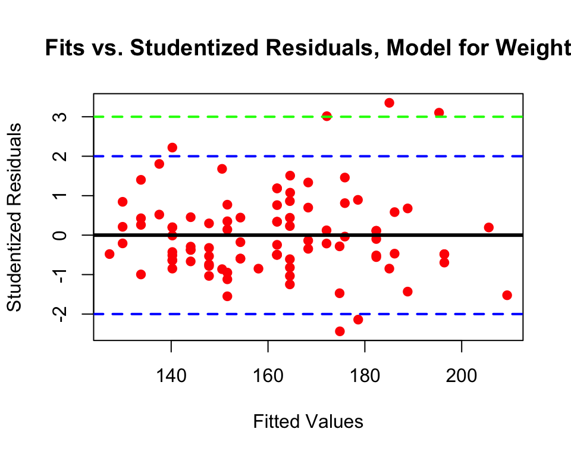

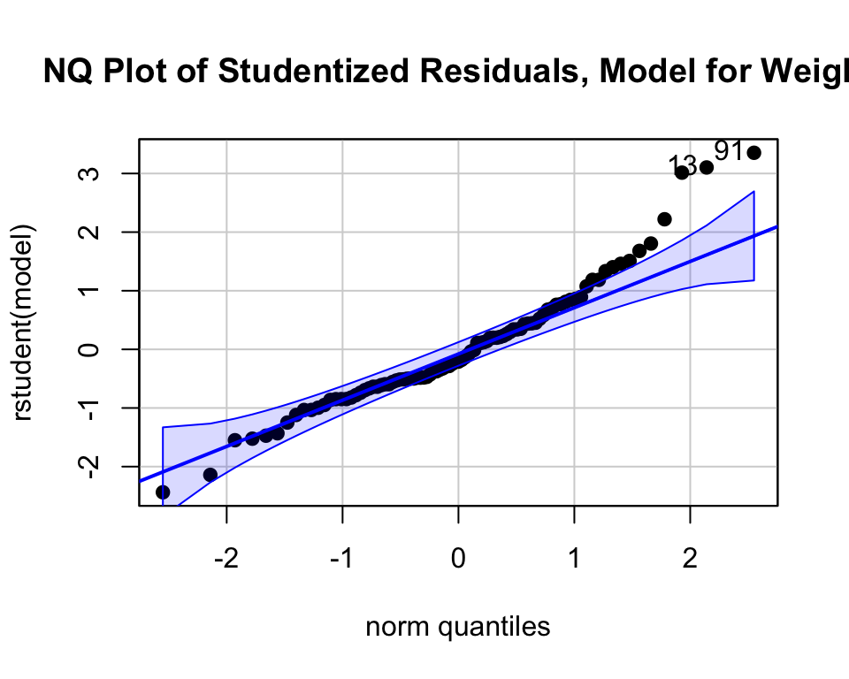

```
## 91 13
## 70 10
```

### ANOVA

Here, an ANOVA was performed between weight and self_perception_weight, as self_perception_weight had multiple categorial responses and had a small p-value in the best subsets regression. As a reminder to the coding of self_perception_weight, it has values 1-6, where 1-5 runs a scale from slim to overweight and 6 represents “i dont think myself in these terms”. Based on the output below, the p-value being 1.23e-05 shows that average weight differs significantly across self_perception_weight categories.

```
##                        Df Sum Sq Mean Sq F value   Pr(>F)
## self_perception_weight  5  24987    4997   7.136 1.23e-05 ***
## Residuals              87  60929     700
## ---
## Signif. codes:  0 '***' 0.001 '**' 0.01 '*' 0.05 '.' 0.1 ' ' 1
```

Here, we do multiple comparisons with Holm correction pairwise t.test. Based on the results, 3+4, 1+5, 2+5, 3+5, 4+5, and 5+6 all have statistically significantly different mean weights.

```
##
##  Pairwise comparisons using t tests with pooled SD
##
## data:  food_clean$weight_clean and food_clean$self_perception_weight
##
##   1       2       3       4       5
## 2 0.72020 -       -       -       -
## 3 1.00000 0.69490 -       -       -
## 4 0.23216 1.00000 0.02835 -       -
## 5 0.00044 0.00046 1.2e-05 0.00662 -
## 6 1.00000 1.00000 1.00000 1.00000 0.00922
##
## P value adjustment method: holm
```

Before choosing a model to compare the ANOVA results to, I first wanted to see if the data is normal and the variances are equal using a qq plot and residuals vs fitted values plot. In the qq plot, the data looks pretty normal, but in the residuals vs fitted values plot, it looks like variance is not constant due to a funnel-like shape. To further support the fact that variances are not equal, the sd_ratio was calculated to be 2.418805.

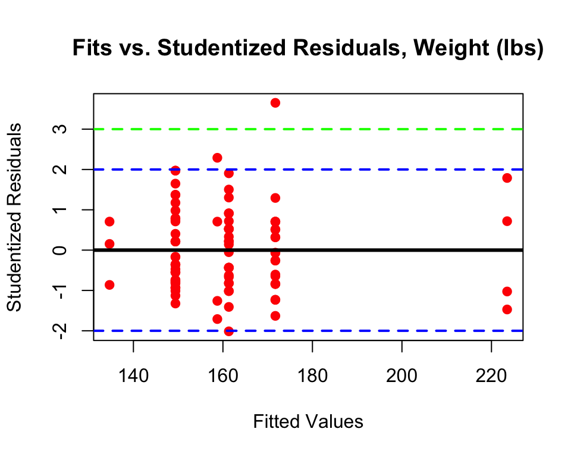

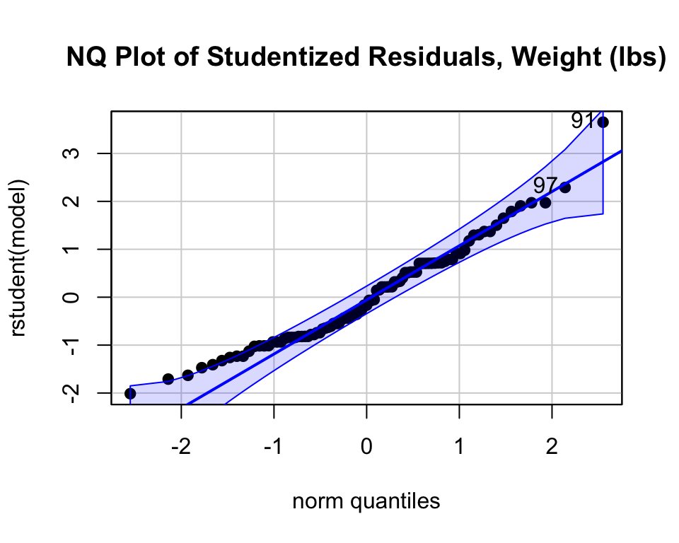

```
## 91 97
## 70 73
```

```
##        1        2        3        4        5        6
## 17.24336 24.48251 24.47071 28.44669 34.57841 41.70831
```

```
## [1] 2.418805
```

Because we have normal populations with unequal variances, we would like to compare with Welch’s ANOVA. When comparing the p-values between Welch’s ANOVA and our original ANOVA, Welch’s ANOVA has a much higher p-value. This difference in p-values is due to Welch’s ANOVA accounting for the unequal variances, thus giving a more conservative p-value.

```
##
##  One-way analysis of means (not assuming equal variances)
##
## data:  weight_clean and self_perception_weight
## F = 4.7045, num df = 5.000, denom df = 10.261, p-value = 0.01727
```

```
##                        Df Sum Sq Mean Sq F value   Pr(>F)
## self_perception_weight  5  24987    4997   7.136 1.23e-05 ***
## Residuals              87  60929     700
## ---
## Signif. codes:  0 '***' 0.001 '**' 0.01 '*' 0.05 '.' 0.1 ' ' 1
```

## Conclusions and Summary

Overall, it looks like weight is primarily associated with gender and how someone perceives their own weight. Grade level seems to have a smaller influence. Gender and grade level make sense as being associated with weight, as men are known to be larger and denser than women due to a difference in body fat, and some students are still in a growing period throughout undergraduate years, whether that be in height or muscle. As for one’s perception of their own weight, it seems that this is mostly applicable when they think they are overweight, as the multiple comparisons test had almost all the pairs include the “overweight” response.